# BorrowerState exploration

## Udacity

in this project I will explore and visualize the dataset of the prosperLoanData

https://s3.amazonaws.com/udacity-hosted-downloads/ud651/prosperLoanData.csv.

```python
# import the packages
import numpy as np
import pandas as pd
import matplotlib.pyplot as plt
import seaborn as sb

%matplotlib inline
```

```python
# load the dataset
df = pd.read_csv('prosperLoanData.csv')
```

```python
print(df.shape)
df.head(6)
```

```
(113937, 81)
```

|  | ListingKey | ListingNumber | ListingCreationDate | CreditGrade | Term | LoanStatus | ClosedDate | BorrowerAPR | BorrowerRate | LenderYield | ... | LP_ServiceFees | LP_CollectionFees | LP_GrossPrincipalLoss | LP_NetPrincipalLoss | LP_NonPrincipalRecoverypayments | PercentFunded | Recommendations | InvestmentFromFriendsCount | InvestmentFromFriendsAmount | Investors |
| --- | --- | --- | --- | --- | --- | --- | --- | --- | --- | --- | --- | --- | --- | --- | --- | --- | --- | --- | --- | --- | --- |
| 0 | 1021339766868145413AB3B | 193129 | 2007-08-26 19:09:29.263000000 | C | 36 | Completed | 2009-08-14 00:00:00 | 0.16516 | 0.1580 | 0.1380 | ... | -133.18 | 0.0 | 0.0 | 0.0 | 0.0 | 1.0 | 0 | 0 | 0.0 | 258 |
| 1 | 10273602499503308B223C1 | 1209647 | 2014-02-27 08:28:07.900000000 | NaN | 36 | Current | NaN | 0.12016 | 0.0920 | 0.0820 | ... | 0.00 | 0.0 | 0.0 | 0.0 | 0.0 | 1.0 | 0 | 0 | 0.0 | 1 |
| 2 | 0EE9337825851032864889A | 81716 | 2007-01-05 15:00:47.090000000 | HR | 36 | Completed | 2009-12-17 00:00:00 | 0.28269 | 0.2750 | 0.2400 | ... | -24.20 | 0.0 | 0.0 | 0.0 | 0.0 | 1.0 | 0 | 0 | 0.0 | 41 |
| 3 | 0EF5356002482715299901A | 658116 | 2012-10-22 11:02:35.010000000 | NaN | 36 | Current | NaN | 0.12528 | 0.0974 | 0.0874 | ... | -108.01 | 0.0 | 0.0 | 0.0 | 0.0 | 1.0 | 0 | 0 | 0.0 | 158 |
| 4 | 0F023589499656230C5E3E2 | 909464 | 2013-09-14 18:38:39.097000000 | NaN | 36 | Current | NaN | 0.24614 | 0.2085 | 0.1985 | ... | -60.27 | 0.0 | 0.0 | 0.0 | 0.0 | 1.0 | 0 | 0 | 0.0 | 20 |
| 5 | 0F05359734824199381F61D | 1074836 | 2013-12-14 08:26:37.093000000 | NaN | 60 | Current | NaN | 0.15425 | 0.1314 | 0.1214 | ... | -25.33 | 0.0 | 0.0 | 0.0 | 0.0 | 1.0 | 0 | 0 | 0.0 | 1 |

6 rows × 81 columns

```python
print(df.columns)
```

```
Index(['ListingKey', 'ListingNumber', 'ListingCreationDate', 'CreditGrade',
       'Term', 'LoanStatus', 'ClosedDate', 'BorrowerAPR', 'BorrowerRate',
       'LenderYield', 'EstimatedEffectiveYield', 'EstimatedLoss',
       'EstimatedReturn', 'ProsperRating (numeric)', 'ProsperRating (Alpha)',
       'ProsperScore', 'ListingCategory (numeric)', 'BorrowerState',
       'Occupation', 'EmploymentStatus', 'EmploymentStatusDuration',
       'IsBorrowerHomeowner', 'CurrentlyInGroup', 'GroupKey',
       'DateCreditPulled', 'CreditScoreRangeLower', 'CreditScoreRangeUpper',
       'FirstRecordedCreditLine', 'CurrentCreditLines', 'OpenCreditLines',
       'TotalCreditLinespast7years', 'OpenRevolvingAccounts',
       'OpenRevolvingMonthlyPayment', 'InquiriesLast6Months', 'TotalInquiries',
       'CurrentDelinquencies', 'AmountDelinquent', 'DelinquenciesLast7Years',
       'PublicRecordsLast10Years', 'PublicRecordsLast12Months',
       'RevolvingCreditBalance', 'BankcardUtilization',
       'AvailableBankcardCredit', 'TotalTrades',
       'TradesNeverDelinquent (percentage)', 'TradesOpenedLast6Months',
       'DebtToIncomeRatio', 'IncomeRange', 'IncomeVerifiable',
       'StatedMonthlyIncome', 'LoanKey', 'TotalProsperLoans',
       'TotalProsperPaymentsBilled', 'OnTimeProsperPayments',
       'ProsperPaymentsLessThanOneMonthLate',
       'ProsperPaymentsOneMonthPlusLate', 'ProsperPrincipalBorrowed',
       'ProsperPrincipalOutstanding', 'ScorexChangeAtTimeOfListing',
       'LoanCurrentDaysDelinquent', 'LoanFirstDefaultedCycleNumber',
       'LoanMonthsSinceOrigination', 'LoanNumber', 'LoanOriginalAmount',
       'LoanOriginationDate', 'LoanOriginationQuarter', 'MemberKey',
       'MonthlyLoanPayment', 'LP_CustomerPayments',
       'LP_CustomerPrincipalPayments', 'LP_InterestandFees', 'LP_ServiceFees',
       'LP_CollectionFees', 'LP_GrossPrincipalLoss', 'LP_NetPrincipalLoss',
       'LP_NonPrincipalRecoverypayments', 'PercentFunded', 'Recommendations',
       'InvestmentFromFriendsCount', 'InvestmentFromFriendsAmount',
       'Investors'],
      dtype='object')
```

```python
df.BorrowerState.unique()
```

```
array(['CO', 'GA', 'MN', 'NM', 'KS', 'CA', 'IL', 'MD', nan, 'AL', 'AZ',
       'VA', 'FL', 'PA', 'OR', 'MI', 'NY', 'LA', 'WI', 'OH', 'NC', 'WA',
       'NV', 'NJ', 'TX', 'AR', 'SC', 'DE', 'MO', 'NE', 'UT', 'DC', 'MA',
       'CT', 'IN', 'KY', 'OK', 'MS', 'WV', 'RI', 'TN', 'ID', 'MT', 'HI',
       'NH', 'VT', 'WY', 'ME', 'AK', 'IA', 'SD', 'ND'], dtype=object)
```

```python
# main features
colus = ['BorrowerState','LoanOriginalAmount', 'EmploymentStatus','BorrowerAPR', 'StatedMonthlyIncome', 'Term', 'ProsperRating (Alpha)']
sub_df = df[colus]
```

```python
sub_df.head()
```

|  | BorrowerState | LoanOriginalAmount | EmploymentStatus | BorrowerAPR | StatedMonthlyIncome | Term | ProsperRating (Alpha) |
| --- | --- | --- | --- | --- | --- | --- | --- |
| 0 | CO | 9425 | Self-employed | 0.16516 | 3083.333333 | 36 | NaN |
| 1 | CO | 10000 | Employed | 0.12016 | 6125.000000 | 36 | A |
| 2 | GA | 3001 | Not available | 0.28269 | 2083.333333 | 36 | NaN |
| 3 | GA | 10000 | Employed | 0.12528 | 2875.000000 | 36 | A |
| 4 | MN | 15000 | Employed | 0.24614 | 9583.333333 | 36 | D |

```python
# statistics
sub_df.describe()
```

|  | LoanOriginalAmount | BorrowerAPR | StatedMonthlyIncome | Term |
| --- | --- | --- | --- | --- |
| count | 113937.00000 | 113912.000000 | 1.139370e+05 | 113937.000000 |
| mean | 8337.01385 | 0.218828 | 5.608026e+03 | 40.830248 |
| std | 6245.80058 | 0.080364 | 7.478497e+03 | 10.436212 |
| min | 1000.00000 | 0.006530 | 0.000000e+00 | 12.000000 |
| 25% | 4000.00000 | 0.156290 | 3.200333e+03 | 36.000000 |
| 50% | 6500.00000 | 0.209760 | 4.666667e+03 | 36.000000 |
| 75% | 12000.00000 | 0.283810 | 6.825000e+03 | 36.000000 |
| max | 35000.00000 | 0.512290 | 1.750003e+06 | 60.000000 |

```python
sub_df.info()
```

```
<class 'pandas.core.frame.DataFrame'>
RangeIndex: 113937 entries, 0 to 113936
Data columns (total 7 columns):
BorrowerState            108422 non-null object
LoanOriginalAmount       113937 non-null int64
EmploymentStatus         111682 non-null object
BorrowerAPR              113912 non-null float64
StatedMonthlyIncome      113937 non-null float64
Term                     113937 non-null int64
ProsperRating (Alpha)    84853 non-null object
dtypes: float64(2), int64(2), object(3)
memory usage: 6.1+ MB
```

```python
# Remove missing borrower APR information and BorrowerState
sub_df = sub_df[~sub_df.BorrowerAPR.isna()]
sub_df = sub_df[~sub_df.BorrowerState.isna()]
```

```python
sub_df.shape
```

```
(108422, 7)
```

```python
sub_df.head()
```

|  | BorrowerState | LoanOriginalAmount | EmploymentStatus | BorrowerAPR | StatedMonthlyIncome | Term | ProsperRating (Alpha) |
| --- | --- | --- | --- | --- | --- | --- | --- |
| 0 | CO | 9425 | Self-employed | 0.16516 | 3083.333333 | 36 | NaN |
| 1 | CO | 10000 | Employed | 0.12016 | 6125.000000 | 36 | A |
| 2 | GA | 3001 | Not available | 0.28269 | 2083.333333 | 36 | NaN |
| 3 | GA | 10000 | Employed | 0.12528 | 2875.000000 | 36 | A |
| 4 | MN | 15000 | Employed | 0.24614 | 9583.333333 | 36 | D |

```python
#removing the NAN values of the ProsperRating
sub_df=sub_df.dropna(subset=['ProsperRating (Alpha)'])
sub_df.shape
```

```
(84853, 7)
```

### What is the structure of the dataset?

The dataset has 113,937 loans with 81 features

### what is the APR ?

https://www.investopedia.com/terms/a/apr.asp#:~:text=The%20term%20%E2%80%9Cannual%20percentage%20rate,income%20earned%20on%20an%20investment

### What is/are the main feature(s) of interest in your dataset?

I will explore the most effective features .

### What features in the dataset do you think will help support your investigation into your feature(s) of interest?

I think that

the total loan amount will affect negatively on the APR

features like : the borrowers stated monthly income, Prosper rating, employment,loan term, status will also have effects on the APR.

## Univariate Exploration

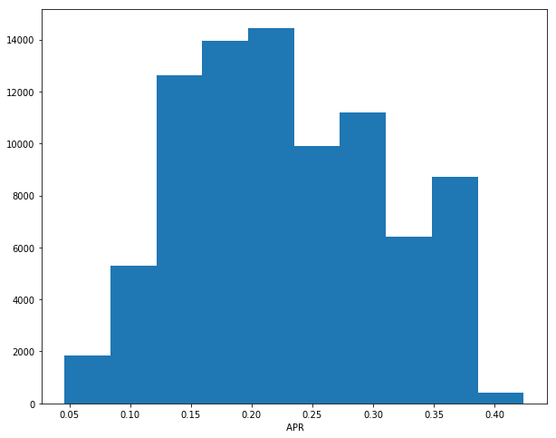

```python
plt.figure(figsize=[10, 8])
plt.hist(data = sub_df, x = 'BorrowerAPR');
plt.xlabel(' APR');
```

```python
sub_df.BorrowerAPR.max()
#max value of the BorrowerAPR
```

```
0.42394999999999999
```

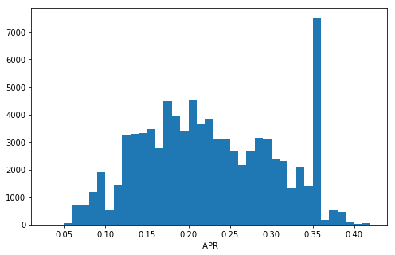

```python
#value_of_max_b_apr=sub_df.BorrowerAPR.max()
bins = np.arange(0.03, 0.42395, 0.01)
plt.figure(figsize=[8, 5])
plt.hist(sub_df.BorrowerAPR, bins = bins);
plt.xlabel(' APR');
```

The distribution of APR

it is multimodal. there is a peak (small one )at 0.1 , large at the center of the distribution , small peak about 0.3 , large at 0.36 A small peak centered at 0.38

Next up, look at the distribution of the first predictor variable of interest: LoanOriginalAmount

```python
sub_df.LoanOriginalAmount.max(),sub_df.LoanOriginalAmount.min()
```

```
(35000, 1000)
```

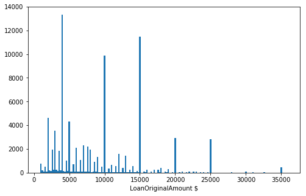

```python
bins = np.arange(900, 36000, 200)
plt.figure(figsize=[8, 5])
plt.hist(sub_df['LoanOriginalAmount'], bins = bins);
plt.xlabel('LoanOriginalAmount $');
```

people like to have a number multiples of 5K :XD

let's take a look at the distributions of other variables

```python
sub_df.StatedMonthlyIncome.max(),sub_df.StatedMonthlyIncome.min()
```

```
(1750002.9166669999, 0.0)
```

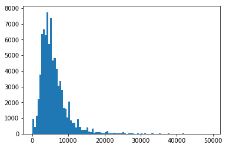

```python
# monthly income distribution
bins_smi = np.arange(0, 50000, 500)
plt.hist(data = sub_df, x = 'StatedMonthlyIncome', bins=bins_smi);
```

The distribution is severely right screwed, most monthly income less than 30k.

```python
# borrowers with stated monthly income greater than -1e5-
len(sub_df[sub_df['StatedMonthlyIncome']>1e5])
```

```
12
```

```python
sub_df[sub_df['StatedMonthlyIncome']>1e5]
```

|  | BorrowerState | LoanOriginalAmount | EmploymentStatus | BorrowerAPR | StatedMonthlyIncome | Term | ProsperRating (Alpha) |
| --- | --- | --- | --- | --- | --- | --- | --- |
| 8066 | IL | 2000 | Employed | 0.35643 | 4.166667e+05 | 36 | HR |
| 17411 | HI | 7500 | Employed | 0.35643 | 4.833333e+05 | 36 | E |
| 35218 | VA | 1000 | Full-time | 0.07389 | 1.083333e+05 | 36 | AA |
| 45028 | KS | 4000 | Self-employed | 0.33973 | 1.500000e+05 | 36 | E |
| 53014 | CA | 4000 | Self-employed | 0.25785 | 6.185478e+05 | 12 | D |
| 53167 | OR | 4000 | Self-employed | 0.35797 | 1.750003e+06 | 36 | HR |
| 57133 | CT | 4000 | Employed | 0.35643 | 4.666667e+05 | 36 | E |
| 59298 | CT | 15000 | Self-employed | 0.24246 | 1.208333e+05 | 36 | C |
| 80075 | FL | 25000 | Employed | 0.20217 | 1.583333e+05 | 36 | C |
| 82831 | WA | 4000 | Self-employed | 0.31012 | 2.500000e+05 | 36 | E |
| 111265 | NY | 12765 | Employed | 0.20593 | 1.087500e+05 | 60 | B |
| 113270 | CA | 2000 | Employed | 0.22712 | 3.944000e+05 | 36 | C |

```python
# the % of borrowers monthly income greater than 25K
(sub_df.StatedMonthlyIncome>25000).sum()/float(sub_df.shape[0])
```

```
0.0048790260803978644
```

0.004879026080397864 of the borrowes their monthly income greater than 25k

I think we should remove them (outlier )

```python
# loans with stated monthly income greater than 30k are removed
#cleaning
sub_df = sub_df[sub_df.StatedMonthlyIncome<=25000]
```

```python
#double check
(sub_df.StatedMonthlyIncome>25000).sum()
```

```
0
```

distributions of term, Prosper rating and employment status

I found some help

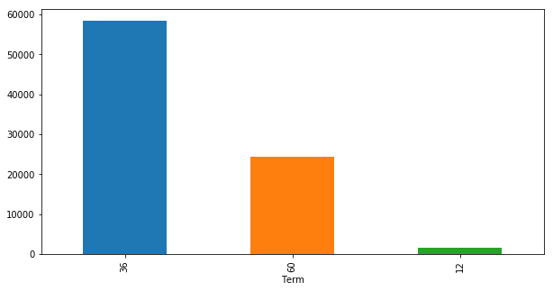

```python
plt.figure(figsize=[10,5 ])
sub_df['Term'].value_counts().plot(kind='bar')
plt.xlabel('Term');
```

36 months are the common duration.

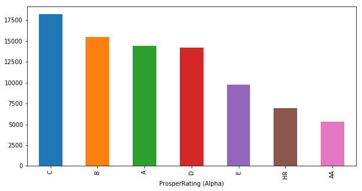

```python
#ProsperRating (Alpha)
plt.figure(figsize=[10,5 ])
sub_df['ProsperRating (Alpha)'].value_counts().plot(kind='bar')
plt.xlabel('ProsperRating (Alpha)');
```

The common ratings are among D to A.

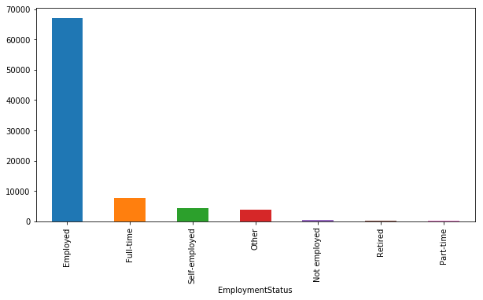

```python
plt.figure(figsize=[10,5 ])
sub_df['EmploymentStatus'].value_counts().plot(kind='bar')
plt.xlabel('EmploymentStatus');
```

most of the borrowers are( employed and full-time).

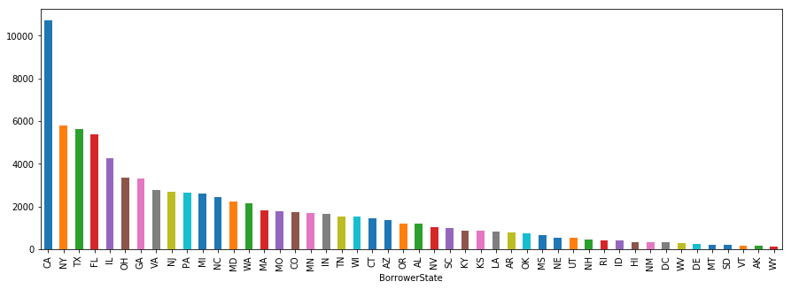

```python
# BorrowerState exploration
plt.figure(figsize=[15,5 ])
sub_df['BorrowerState'].value_counts().plot(kind='bar')
plt.xlabel('BorrowerState');
```

California is the highest BorrowerState

### Discuss the distribution(s) of your variable(s) of interest. Were there any unusual points? Did you need to perform any transformations?

The distribution of APR looks multimodal. Most values are at the range of (0.05 : 0.4). There are no need to perform any transformations.

## Bivariate Exploration

correlations present between features in the data.

num_var = ['LoanOriginalAmount', 'BorrowerAPR', 'StatedMonthlyIncome']

categorical_variable = ['Term', 'ProsperRating (Alpha)', 'EmploymentStatus','BorrowerState']

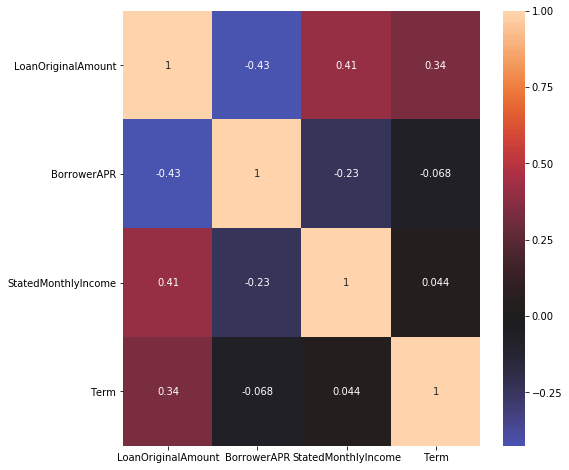

```python
# correlation
plt.figure(figsize = [8, 8])
sb.heatmap(sub_df.corr(), annot = True, center = 0);
```

there are some correlations

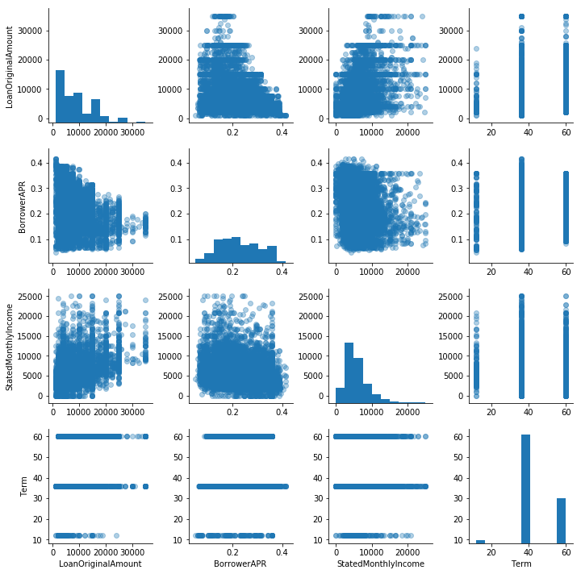

```python
#sample 9000
g = sb.PairGrid(data = sub_df.sample(9000).dropna()).map_diag(plt.hist)
g.map_offdiag(plt.scatter, alpha=0.35);
```

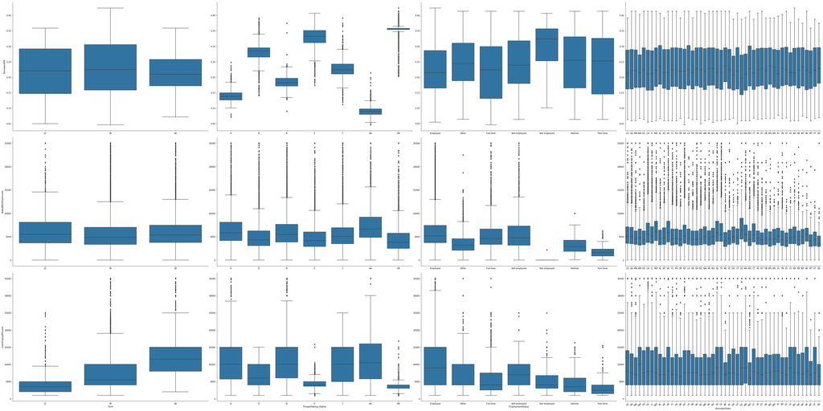

```python
# categorical features vs matrix of numeric features

def boxgrid(x, y, **kwargs):
    """ https://github.com/mwaskom/seaborn/issues/915#issuecomment-595414614"""
    """he has solved the issue with simple trick"""
    default_color = sb.color_palette()[0]
    sb.boxplot(x, y, color = default_color)
plt.figure(figsize = [20, 20]);
a = sb.PairGrid(data = sub_df, y_vars = ['BorrowerAPR', 'StatedMonthlyIncome', 'LoanOriginalAmount'], x_vars = ['Term', 'ProsperRating (Alpha)', 'EmploymentStatus','BorrowerState'], size = 9, aspect = 1.5)

a.map(boxgrid);
plt.xticks(rotation=40);
```

loan amount increased with loan term. The APR decreases with better_rating. higher Prosper_ratings borrowers have the lowest APR. So the Prosper_rating has a high effect on borrower_APR. Borrowers with good rating also have larger_monthly_income and loan_amount.

(Employed, self-employed and full time) have more monthly income and loan amount *#than*(part-time, retired and not employed borrowers).

relationships between the four categorical features.

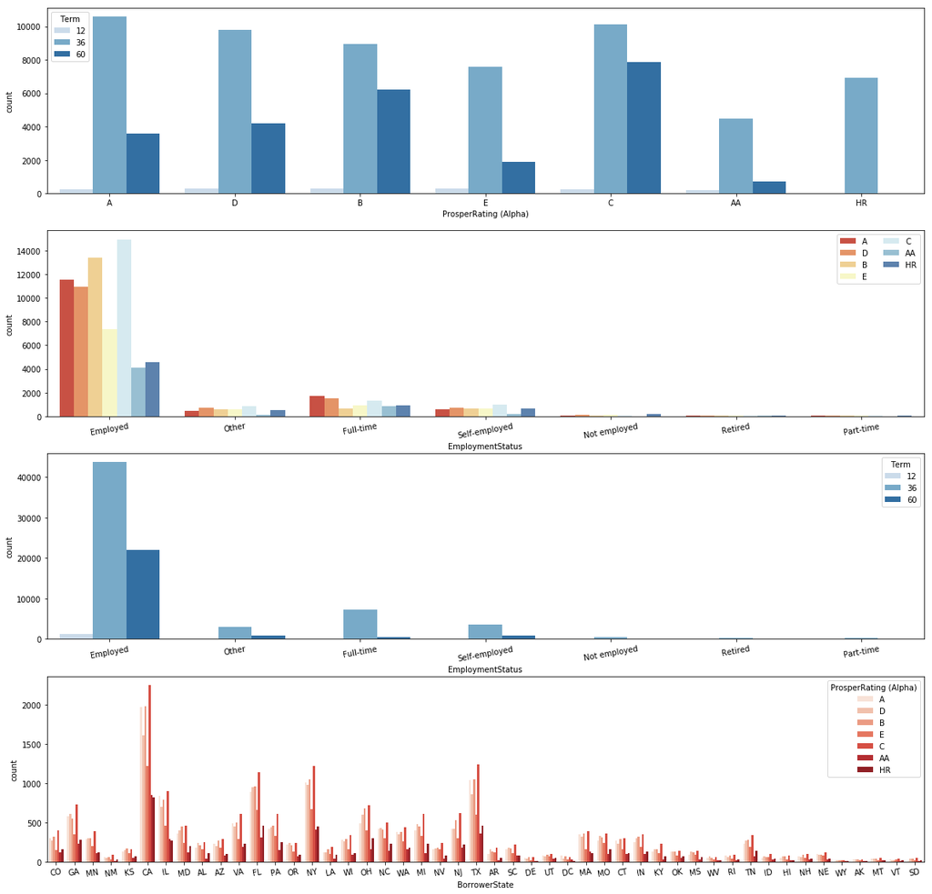

```python
plt.figure(figsize = [20, 20])

# Prospe_rating vs term
plt.subplot(4, 1, 1)
sb.countplot(data = sub_df, x = 'ProsperRating (Alpha)', hue = 'Term', palette = 'Blues')



# Prosper-rating vs employment_status
ax = plt.subplot(4, 1, 2)
sb.countplot(data = sub_df, x = 'EmploymentStatus', hue = 'ProsperRating (Alpha)', palette = 'RdYlBu')
ax.legend(loc = 1, ncol = 2); # re-arrange legend to remove overlapping
plt.xticks(rotation=10);

# employment_status vs term
ax = plt.subplot(4, 1, 3)
sb.countplot(data = sub_df, x = 'EmploymentStatus', hue = 'Term', palette = 'Blues')
plt.xticks(rotation=10)

plt.subplot(4, 1, 4)
sb.countplot(data = sub_df, x = 'BorrowerState', hue = 'ProsperRating (Alpha)', palette = 'Reds')
plt.xticks(rotation=10);
```

> The employment status variable

there are no enough data on part-time, retired and not employed borrowers to show the interaction with term and Prosper_rating.

> interaction between term and Prosper rating.

the states somehow have the same ProsperRating (Alpha)

(12.7%) of the loans belong to borrowers from California.

#### bivariate relationships

let's see how APR and loan_original_amount are related to one another for (all of the data).

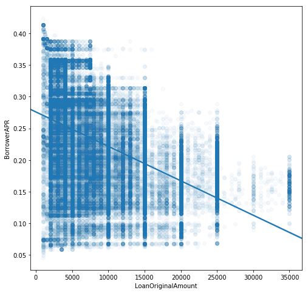

```python
plt.figure(figsize = [8, 8])
sb.regplot( x = sub_df['LoanOriginalAmount'], y = sub_df['BorrowerAPR'], scatter_kws={'alpha':0.03});
```

the borrower APR is negatively correlated with loan amount.

### some of the relationships you observed in this part of the investigation. How did the feature(s) of interest vary with other features in the dataset?

The Prosper rating also has a high effect on the APR, with the better rating this effect decreases.

at different size of the loan amount, the APR has a large range ,(in the higher loan it becomes small)

### Did you observe any interesting relationships between the other features (not the main feature(s) of interest)?

loan_original_amount is positively correlated with the stated_monthly_income, I think it's obvious since borrowers with more monthly income could loan more money. It also shows that borrowers with better rating also have larger monthly income and loan amount. There is a (relation) interaction between prosper rating and term. there are more 60 month loans on B and C ratings. There is only 36 months loans for HR rating borrowers.

## Multivariate Exploration

the analysis of categorical variable (Prosper rating and term) rules in the relationship between APR and loan_original_amount.

[figure not shown]

```python
ni=sb.FacetGrid( data= sub_df ,aspect=1.2, col='Term', col_wrap=4)
ni.map(sb.regplot,x = sub_df['LoanOriginalAmount'], y = sub_df['BorrowerAPR'], x_jitter=0.04, scatter_kws={'alpha':0.1}).add_legend();
```

[figure not shown]

```python
ni=sb.FacetGrid(data=sub_df, aspect=1.2, col='ProsperRating (Alpha)', col_wrap=4)
ni.map(sb.regplot, x = sub_df['LoanOriginalAmount'], y = sub_df['BorrowerAPR'], x_jitter=0.04, scatter_kws={'alpha':0.1}).add_legend();
```

[output not shown]

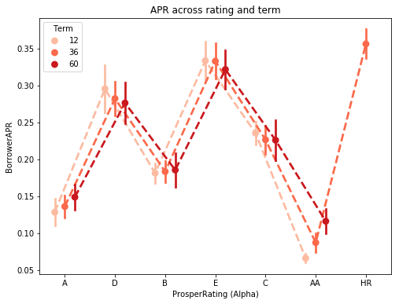

```python
fig = plt.figure(figsize = [8,6])
sb.pointplot(x=sub_df['ProsperRating (Alpha)'], y =sub_df['BorrowerAPR'], hue =sub_df['Term'],palette = 'Reds', linestyles = '--', dodge = 0.4, ci='sd')
plt.title('APR across rating and term')
```

Interestingly, the APR decrease with the increase of borrow term for people with HR-C raings. But for people with B-AA ratings, the APR increase with the increase of borrow term. which make sense

> the rating and term_effects on stated_monthly_income and loan_original_amount variables

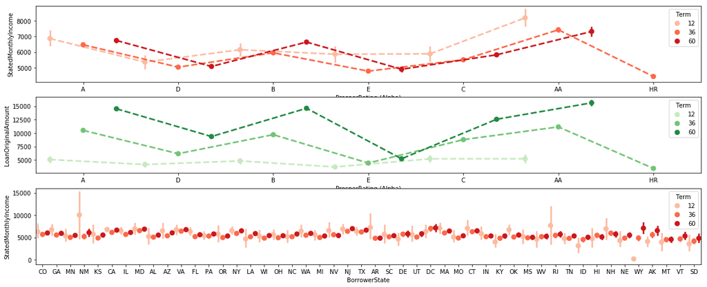

```python
fig, ax = plt.subplots(nrows=3, figsize=[20,8])
sb.pointplot(x = sub_df['ProsperRating (Alpha)'], y =sub_df[ 'StatedMonthlyIncome'], hue = sub_df['Term'],palette = 'Reds', linestyles = '--', dodge = 0.7, ax=ax[0]);
sb.pointplot( x = sub_df['ProsperRating (Alpha)'], y =sub_df ['LoanOriginalAmount'], hue =  sub_df['Term'],palette = 'Greens', linestyles = '--', dodge = 0.7, ax=ax[1]);
sb.pointplot(x = sub_df['BorrowerState'], y =sub_df[ 'StatedMonthlyIncome'], hue = sub_df['Term'],palette = 'Reds', linestyles = '', dodge = 0.7, ax=ax[2]);
```

for loan amount, there is an interaction between term and rating.

### Talk about some of the relationships you observed in this part of the investigation. Were there features that strengthened each other in terms of looking at your feature(s) of interest?

by looking at the impact of the Prosper_rating,I extended my investigation of APR VS loan_amount .

The multivariate exploration showed us the relationship between APR and loan_amount.

### Were there any interesting or surprising interactions between features

the APR decrease with the increase of borrow term for people with *HR-C* raings. But for people with *B-AA*, the APR increase with the borrow term.

the states it's a quiet intersting